# Biomarker_collecitons_summary

Wendel Raymond

October 3, 2018

# Biomarker collections summary from summer 2018

Here we will take a look at all the tissue samples taken for biomarker analysis from the 2018 field season. From this summary analysis we hope to identify the spatial and treatment coverage of the samples and therefore be able to decide what samples to actually process.

## Biomarker collections as core eelgrass sites

I collected a lot of samples but some of them are form places other than the core eelgrass sites. Below we will look at only those data and later we look at the other data.

### Eelgrass site tissue samples

Map

[interactive chart not shown]

Data

|  | Site | Species_common | n |
| --- | --- | --- | --- |
| 1 |  | Butter clam | 3 |
| 2 | 2018_H_01 | Bentnose Macoma | 3 |
| 3 | 2018_H_01 | Butter clam | 1 |
| 4 | 2018_H_01 | Cockle | 5 |
| 5 | 2018_H_01 | Dock shrimp | 3 |
| 6 | 2018_H_01 | Dungeness crab | 4 |
| 7 | 2018_H_01 | Eelgrass | 3 |
| 8 | 2018_H_01 | Eelgrass diatoms | 5 |
| 9 | 2018_H_01 | Fucus | 3 |
| 10 | 2018_H_01 | Helmet crab | 6 |

[output cut: 109 more lines]

An alternative view

|  | Site | Bentnose Macoma | Butter clam | Cockle | Dock shrimp | Dungeness crab | Eelgrass | Eelgrass diatoms | epiphytic bryozoan | Fucus | Helmet crab | Idotea | Kelp crab | Limpet | Macoma sp. | Micophytobenthos | Nereid worm | Particulate organic matter | Pointed Macoma | Red rock crab | Sabellid worm | Shiner perch | Snake prickleback | Spaghetti worm | Staghorn sculpin | Steamer clam | Sugar kelp | Ulva |
| --- | --- | --- | --- | --- | --- | --- | --- | --- | --- | --- | --- | --- | --- | --- | --- | --- | --- | --- | --- | --- | --- | --- | --- | --- | --- | --- | --- | --- |
| 1 |  |  | 3 |  |  |  |  |  |  |  |  |  |  |  |  |  |  |  |  |  |  |  |  |  |  |  |  |  |
| 2 | 2018_H_01 | 3 | 1 | 5 | 3 | 4 | 3 | 5 |  | 3 | 6 | 3 | 1 | 3 |  |  | 2 | 3 | 1 |  |  | 3 | 4 | 4 | 3 |  | 5 | 3 |
| 3 | 2018_H_02 | 2 | 1 | 1 | 3 | 1 | 3 | 2 | 2 | 3 | 3 | 3 |  | 3 |  |  |  | 3 | 1 |  |  | 3 | 4 | 3 | 10 | 3 | 3 | 3 |
| 4 | 2018_H_03 | 1 | 1 |  |  | 6 | 3 | 1 |  | 3 | 3 | 3 |  | 2 |  |  |  | 1 | 1 |  |  | 4 | 4 | 3 | 4 | 3 | 1 | 3 |
| 5 | 2018_L_01 |  | 3 |  | 4 | 5 | 3 | 2 |  | 3 | 1 | 3 |  | 1 | 1 | 3 | 1 | 3 | 1 | 4 |  | 3 |  | 2 | 3 |  |  | 3 |
| 6 | 2018_L_02 |  | 3 |  | 4 | 2 | 3 |  |  | 3 |  | 5 |  | 3 | 3 | 3 |  | 3 |  | 5 |  | 5 | 3 | 2 | 4 |  | 3 | 3 |
| 7 | 2018_L_03 | 3 | 3 |  | 3 | 2 | 3 | 1 |  | 3 | 3 | 3 |  | 3 | 1 |  | 1 | 3 | 2 | 4 | 1 | 3 | 2 | 3 | 3 |  | 6 | 3 |

### Whats the goal here?

The goal is to characterize eelgrass trophic relationships/feeding relationships with SI and FA. To do this we want to have representative samples of the various trophic levels so that we can look for biomarker transfer. Our main hypothesis is that the trophic relationships in AK are similar to CA and the Baltic Sea. What are these trophic levels? Notes that these are rough levels and the lines between them are likely not sharp

1. Primary producers
- Eelgrass
- Green algae
- Brown algae
- POM
- Diatoms
- Microphytobenthos
2. Primary consumers - multiple feeding modes
- Limpets (direct)
- Idotea (direct)
- Butter clam (filter)
- Cockle (filter)
- Macoma sp. clam (deposit)
- Spaghetti worm (deposit)
3. Predators
- Dock shrimp
- Crabs (Dungy, red rock, Helmet, Kelp)
- Fishes (Staghorn sculpin, Shiner perch, snake prickleback)
- Nereid worms

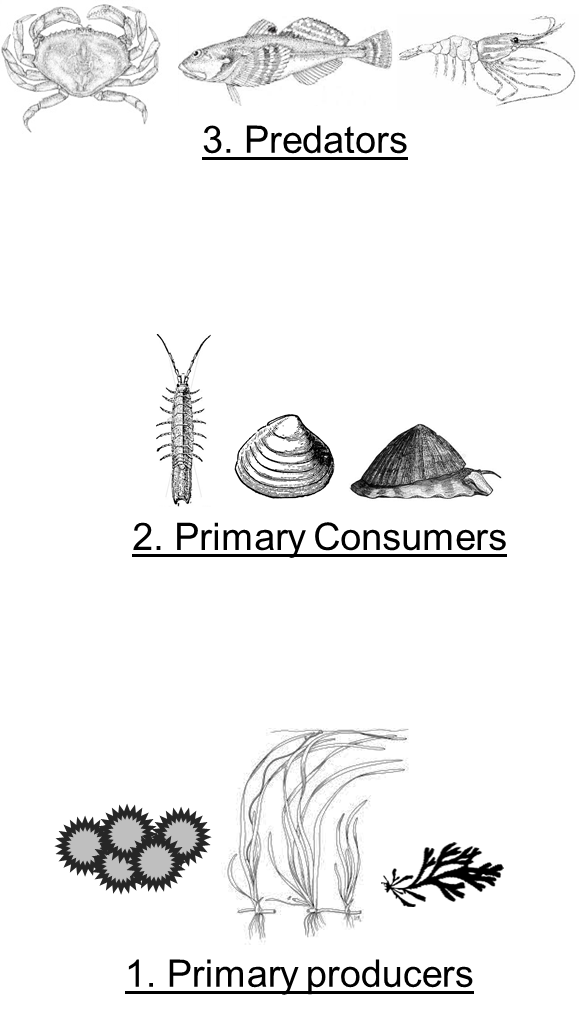

lets group sample by these trophic levels and look again

|  | Collection_Date | Site | Place_name | Sea_otter_region | Latitude | Longitude | Biomarker_ID | Species_common | Species_scientific | sp_code | Max_length_1_mm | Max_length_2_mm | Max_length_3_mm | Max_length_4_mm | Max_length_5_mm | Max_length_6_mm | Max_length_7_mm | Max_length_8_mm | Max_length_9_mm | Max_length_10_mm | Max_length_11_mm | Max_length_12_mm | Max_length_13_mm | Max_length_14_mm | sex | n_pooled | Notes | Trophic_level |
| --- | --- | --- | --- | --- | --- | --- | --- | --- | --- | --- | --- | --- | --- | --- | --- | --- | --- | --- | --- | --- | --- | --- | --- | --- | --- | --- | --- | --- |
| 1 | 7/14/2018 | 2018_H_01 | Kaguk Cove | High | 55.735283 | -133.295189 | B_096 | Helmet crab | Telmessus cheiragonus | CRBHEL | 40 |  |  |  |  |  |  |  |  |  |  |  |  |  | M | 1 |  | 3 |
| 2 | 7/14/2018 | 2018_H_01 | Kaguk Cove | High | 55.735283 | -133.295189 | B_097 | Helmet crab | Telmessus cheiragonus | CRBHEL | 35 |  |  |  |  |  |  |  |  |  |  |  |  |  | M | 1 |  | 3 |
| 3 | 7/14/2018 | 2018_H_01 | Kaguk Cove | High | 55.735283 | -133.295189 | B_098 | Helmet crab | Telmessus cheiragonus | CRBHEL | 32 | 30 |  |  |  |  |  |  |  |  |  |  |  |  | F, M | 2 |  | 3 |
| 4 | 7/14/2018 | 2018_H_01 | Kaguk Cove | High | 55.735283 | -133.295189 | B_099 | Kelp crab | Pugettia producta | CRBKLP | 40 |  |  |  |  |  |  |  |  |  |  |  |  |  | M | 1 |  | 3 |
| 5 | 7/14/2018 | 2018_H_01 | Kaguk Cove | High | 55.735283 | -133.295189 | B_100 | Dungeness crab | Metacarcinus magister | CRBDUN | 37 | 35 | 40 |  |  |  |  |  |  |  |  |  |  |  | F, F, F | 3 |  | 3 |
| 6 | 7/14/2018 | 2018_H_01 | Kaguk Cove | High | 55.735283 | -133.295189 | B_101 | Ulva | Ulva sp. | ULVA |  |  |  |  |  |  |  |  |  |  |  |  |  |  |  | 1 |  | 1 |
| 7 | 7/14/2018 | 2018_H_01 | Kaguk Cove | High | 55.735283 | -133.295189 | B_102 | Ulva | Ulva sp. | ULVA |  |  |  |  |  |  |  |  |  |  |  |  |  |  |  | 1 |  | 1 |
| 8 | 7/14/2018 | 2018_H_01 | Kaguk Cove | High | 55.735283 | -133.295189 | B_103 | Ulva | Ulva sp. | ULVA |  |  |  |  |  |  |  |  |  |  |  |  |  |  |  | 1 |  | 1 |
| 9 | 7/14/2018 | 2018_H_01 | Kaguk Cove | High | 55.735283 | -133.295189 | B_104 | Eelgrass | Zostera marina | EELGRS |  |  |  |  |  |  |  |  |  |  |  |  |  |  |  | 1 |  | 1 |
| 10 | 7/14/2018 | 2018_H_01 | Kaguk Cove | High | 55.735283 | -133.295189 | B_105 | Eelgrass | Zostera marina | EELGRS |  |  |  |  |  |  |  |  |  |  |  |  |  |  |  | 1 |  | 1 |

[output cut: 333 more lines]

Alternative view

|  | Site | Species_common | Trophic_level | n |
| --- | --- | --- | --- | --- |
| 1 |  | Butter clam | 2 | 3 |
| 2 | 2018_H_01 | Bentnose Macoma | 2 | 3 |
| 3 | 2018_H_01 | Butter clam | 2 | 1 |
| 4 | 2018_H_01 | Cockle | 2 | 5 |
| 5 | 2018_H_01 | Dock shrimp | 3 | 3 |
| 6 | 2018_H_01 | Dungeness crab | 3 | 4 |
| 7 | 2018_H_01 | Eelgrass | 1 | 3 |
| 8 | 2018_H_01 | Eelgrass diatoms | 1 | 5 |
| 9 | 2018_H_01 | Fucus | 1 | 3 |
| 10 | 2018_H_01 | Helmet crab | 3 | 6 |

[output cut: 109 more lines]

|  | Species_common | V1 | 2018_H_01 | 2018_H_02 | 2018_H_03 | 2018_L_01 | 2018_L_02 | 2018_L_03 | Trophic_level |
| --- | --- | --- | --- | --- | --- | --- | --- | --- | --- |
| 1 | Bentnose Macoma |  | 3 | 2 | 1 |  |  | 3 | 2 |
| 5 | Butter clam | 3 | 1 | 1 | 1 | 3 | 3 | 3 | 2 |
| 12 | Cockle |  | 5 | 1 |  |  |  |  | 2 |
| 14 | Dock shrimp |  | 3 | 3 |  | 4 | 4 | 3 | 3 |
| 19 | Dungeness crab |  | 4 | 1 | 6 | 5 | 2 | 2 | 3 |
| 25 | Eelgrass |  | 3 | 3 | 3 | 3 | 3 | 3 | 1 |
| 31 | Eelgrass diatoms |  | 5 | 2 | 1 | 2 |  | 1 | 1 |
| 36 | epiphytic bryozoan |  |  | 2 |  |  |  |  | 1 |
| 37 | Fucus |  | 3 | 3 | 3 | 3 | 3 | 3 | 1 |
| 43 | Helmet crab |  | 6 | 3 | 3 | 1 |  | 3 | 3 |

[output cut: 17 more lines]

### What samples should be processed?

Total 273 samples! Whoo, that might be to many :/ Maybe there is a way to reduce replication of some of these. For example the marcopytes could be reduced to 2 samples per site so that would remove 18 samples (255)?

## Other data

We are now entering “beyond my dissertation” territory. Over the summer I worked with Tom Bell on collecting spectral reflectance data from a bunch of Macrocystis. From each sampling location I also collected a tissue sample for %N analysis but we could also run SI and FA from it. There may be an opportunity here to relate spectral data to FA content. If we want to do this we should have a larger conversation with Tom. He understands this stuff.

|  | Collection_Date | Site | Place_name | Sea_otter_region | Latitude | Longitude | Biomarker_ID | Species_common | Species_scientific | sp_code | Max_length_1_mm | Max_length_2_mm | Max_length_3_mm | Max_length_4_mm | Max_length_5_mm | Max_length_6_mm | Max_length_7_mm | Max_length_8_mm | Max_length_9_mm | Max_length_10_mm | Max_length_11_mm | Max_length_12_mm | Max_length_13_mm | Max_length_14_mm | sex | n_pooled | Notes |
| --- | --- | --- | --- | --- | --- | --- | --- | --- | --- | --- | --- | --- | --- | --- | --- | --- | --- | --- | --- | --- | --- | --- | --- | --- | --- | --- | --- |
| 1 | 7/24/2018 |  | Middle Island |  |  |  | B_211 | Giant Kelp | Macrocystis pyrifera | GIAKLP |  |  |  |  |  |  |  |  |  |  |  |  |  |  |  |  | reflectance measured |
| 2 | 7/24/2018 |  | North Pass |  |  |  | B_215 | Giant Kelp | Macrocystis pyrifera | GIAKLP |  |  |  |  |  |  |  |  |  |  |  |  |  |  |  |  | reflectance measured |
| 3 | 7/24/2018 |  | Sukkwan |  |  |  | B_219 | Giant Kelp | Macrocystis pyrifera | GIAKLP |  |  |  |  |  |  |  |  |  |  |  |  |  |  |  |  | reflectance measured |
| 4 | 7/24/2018 |  | South Pass |  |  |  | B_220 | Giant Kelp | Macrocystis pyrifera | GIAKLP |  |  |  |  |  |  |  |  |  |  |  |  |  |  |  |  | reflectance measured |
| 5 | 7/24/2018 |  | Sentinal Island |  |  |  | B_221 | Giant Kelp | Macrocystis pyrifera | GIAKLP |  |  |  |  |  |  |  |  |  |  |  |  |  |  |  |  | reflectance measured |
| 6 | 7/25/2018 |  | Inner Fish Egg |  |  |  | B_222 | Giant Kelp | Macrocystis pyrifera | GIAKLP |  |  |  |  |  |  |  |  |  |  |  |  |  |  |  | 1 | reflectance measured |
| 7 | 7/25/2018 |  | South Fish Egg |  |  |  | B_223 | Giant Kelp | Macrocystis pyrifera | GIAKLP |  |  |  |  |  |  |  |  |  |  |  |  |  |  |  | 1 | reflectance measured |
| 8 | 7/25/2018 |  | Parida Reef |  |  |  | B_224 | Giant Kelp | Macrocystis pyrifera | GIAKLP |  |  |  |  |  |  |  |  |  |  |  |  |  |  |  | 1 | reflectance measured |
| 9 | 7/25/2018 |  | Blanquizal |  |  |  | B_225 | Giant Kelp | Macrocystis pyrifera | GIAKLP |  |  |  |  |  |  |  |  |  |  |  |  |  |  |  | 1 | reflectance measured |
| 10 | 7/25/2018 |  | Nossuk Anchorage |  |  |  | B_227 | Giant Kelp | Macrocystis pyrifera | GIAKLP |  |  |  |  |  |  |  |  |  |  |  |  |  |  |  | 1 | reflectance measured |

[output cut: 5 more lines]